# Practical Machine Learning Course Project

Jacques Belissent

September 21, 2014

## Data exploration

(make sure you change the directory to that where the data has been extracted, using setwd())

```r
setwd("/Users/jbelis/Documents/pml")
training = read.csv("pml-training.csv")
testing = read.csv("pml-testing.csv")
library(caret)
```

A number of variables are never available in the test data set. We therefore generate a new training data set excluding these variables.

```r
useful_cols = sapply(testing, function(x) !all(is.na(x)))
```

In addition to these columns, we exclude the following columns that have no prediction value: - X : test index, assumed to be artifically correlated with the class variable - user_name : uncorrelated, assuming any correlation would be artificial - raw_timestamp_part_1 : discrete timestamp - raw_timestamp_part_2 : integer with stable distribution - cvtd_timestamp : discrete date/time - new_window : constant in test set - num_window : integer assumed to be artifically correlated with the class variable

So the data sets are hereby reduced:

```r
useful_cols[1:7] = FALSE
training1 = training[,useful_cols]
testing1 = testing[,useful_cols]
```

## Dataset Slicing

The test data does not include the class variable. We therefore have to split the training set into training and model validation data sets, by setting out 30% of records for validation

```r
set.seed(123)
inTrain = createDataPartition(y=training1$classe, p=.7, list=FALSE)
cv1 = training1[-inTrain,]
train1 = training1[inTrain,]
```

## Preprocessing

One side benefit of removing columns during data exploration is that we end up with a data set without missing data (which was not the case to begin with), and consisting only of numerical data. Normalization is handled as part or training. The data set does not include near-zero-variables, and while there are highly correlated variables, there is no a uge amount of them.

I spent some time experimenting with PCA but the experiment did not yield very high quality predictors, as illustrated in the plot below. The 2 most critical PCA components plotted against each other do not succeed in separating the classes.

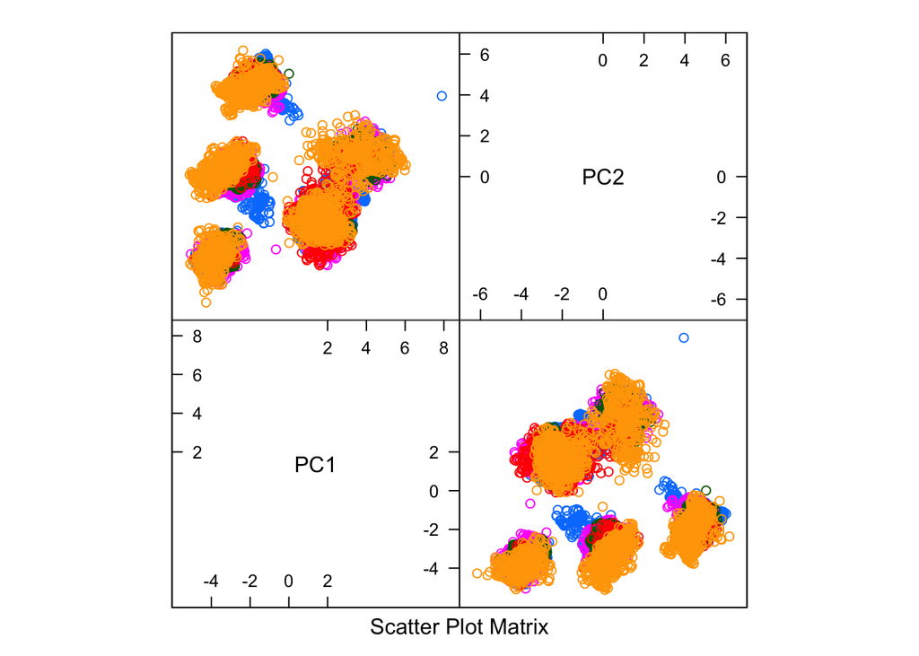

```r
preProc = preProcess(train1[,-53], method="pca", pcaComp=2)
pca1 = predict(preProc, train1[,-53])
featurePlot(x=pca1, y=train1$classe, plot="pairs")
```

## Model selection

I am not going to bore you too much with how I arrived at the conclusion that using boosting provided a vastly better accuracy. In the process, I tried what feels like a large number of classifiers to the chagrin of my overheating laptop. All this despite the fact that the first line of the lecture notes on boosting is

> 1. Take lots of (possibly) weak predictors

And what we have is precisely a set of 52 week predictors, as shown by the results of an initial decision tree prediction attempt: a 55% accuracy rate.

```r
treefit = train(classe ~ ., method="rpart", preProcess=c("center","scale"), data=train1)
confusionMatrix(predict(treefit, newdata=cv1), cv1$classe)
```

```
## Confusion Matrix and Statistics
##
##           Reference
## Prediction    A    B    C    D    E
##          A 1061  235   27   64   13
##          B  163  631   42  133  281
##          C  341  230  819  509  247
##          D  102   43  138  258   60
##          E    7    0    0    0  481
##
## Overall Statistics
##
##                Accuracy : 0.552
##                  95% CI : (0.539, 0.565)
##     No Information Rate : 0.284
##     P-Value [Acc > NIR] : <2e-16
##
##                   Kappa : 0.437
##  Mcnemar's Test P-Value : <2e-16
##
## Statistics by Class:
##
##                      Class: A Class: B Class: C Class: D Class: E
## Sensitivity             0.634    0.554    0.798   0.2676   0.4445
## Specificity             0.919    0.870    0.727   0.9303   0.9985
## Pos Pred Value          0.758    0.505    0.382   0.4293   0.9857
## Neg Pred Value          0.863    0.890    0.945   0.8664   0.8886
## Prevalence              0.284    0.194    0.174   0.1638   0.1839
## Detection Rate          0.180    0.107    0.139   0.0438   0.0817
## Detection Prevalence    0.238    0.212    0.365   0.1021   0.0829
## Balanced Accuracy       0.777    0.712    0.763   0.5990   0.7215
```

```r
treefit$finalModel
```

```
## n= 13737
##
## node), split, n, loss, yval, (yprob)
##       * denotes terminal node
##
##   1) root 13737 9831 A (0.28 0.19 0.17 0.16 0.18)
##     2) roll_belt< 1.055 12580 8681 A (0.31 0.21 0.19 0.18 0.11)
##       4) pitch_forearm< -1.318 1238   45 A (0.96 0.036 0 0 0) *
##       5) pitch_forearm>=-1.318 11342 8636 A (0.24 0.23 0.21 0.2 0.12)
##        10) yaw_belt>=1.902 550   56 A (0.9 0.044 0 0.049 0.0091) *
##        11) yaw_belt< 1.902 10792 8203 B (0.2 0.24 0.22 0.21 0.13)
##          22) magnet_dumbbell_z< -0.958 1420  615 A (0.57 0.28 0.051 0.075 0.025) *
##          23) magnet_dumbbell_z>=-0.958 9372 7048 C (0.15 0.23 0.25 0.23 0.14)
##            46) pitch_belt< -1.938 576   96 B (0.014 0.83 0.092 0.033 0.028) *
##            47) pitch_belt>=-1.938 8796 6525 C (0.16 0.19 0.26 0.24 0.15)
##              94) magnet_dumbbell_x>=-0.3447 3783 2642 B (0.17 0.3 0.097 0.24 0.19)
##               188) roll_belt< 0.8478 2357 1340 B (0.17 0.43 0.025 0.13 0.24) *
##               189) roll_belt>=0.8478 1426  830 D (0.18 0.087 0.22 0.42 0.097) *
##              95) magnet_dumbbell_x< -0.3447 5013 3110 C (0.15 0.11 0.38 0.24 0.12) *
##     3) roll_belt>=1.055 1157    7 E (0.0061 0 0 0 0.99) *
```

A look at the tree model above shows that several leaf nodes, especially for classes B, C, D do not lead to high accuracy.

Fortunately, much better results are obtained using boosting with trees (gbm).

```r
date()
```

```
## [1] "Sun Sep 21 22:08:55 2014"
```

```r
fit = train(classe ~ ., method="gbm", preProcess=c("center","scale"), data=train1, verbose=FALSE)
date()
```

```
## [1] "Sun Sep 21 22:34:44 2014"
```

```r
confusionMatrix(predict(fit, newdata=cv1), cv1$classe)
```

```
## Confusion Matrix and Statistics
##
##           Reference
## Prediction    A    B    C    D    E
##          A 1645   46    0    0    5
##          B   20 1061   45    2    9
##          C    6   30  966   51    7
##          D    2    2   13  906   16
##          E    1    0    2    5 1045
##
## Overall Statistics
##
##                Accuracy : 0.955
##                  95% CI : (0.95, 0.961)
##     No Information Rate : 0.284
##     P-Value [Acc > NIR] : < 2e-16
##
##                   Kappa : 0.944
##  Mcnemar's Test P-Value : 6.26e-10
##
## Statistics by Class:
##
##                      Class: A Class: B Class: C Class: D Class: E
## Sensitivity             0.983    0.932    0.942    0.940    0.966
## Specificity             0.988    0.984    0.981    0.993    0.998
## Pos Pred Value          0.970    0.933    0.911    0.965    0.992
## Neg Pred Value          0.993    0.984    0.988    0.988    0.992
## Prevalence              0.284    0.194    0.174    0.164    0.184
## Detection Rate          0.280    0.180    0.164    0.154    0.178
## Detection Prevalence    0.288    0.193    0.180    0.160    0.179
## Balanced Accuracy       0.985    0.958    0.961    0.967    0.982
```

The 96% accuracy is achieved for a tree depth of 3 and 150 iterations.

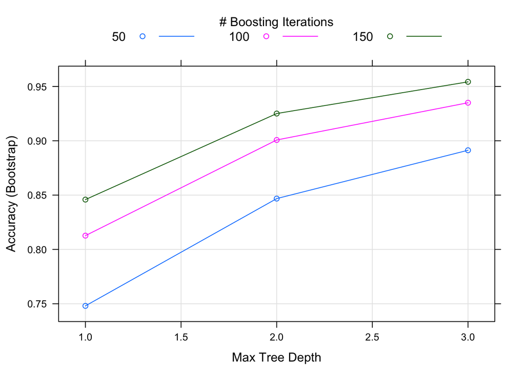

```r
plot(fit)
```

## Prediction

The following is the prediction vector for the test set, using the model created above.

```r
submission = predict(fit, newdata=testing1)
submission
```

```
##  [1] B A B A A E D B A A B C B A E E A B B B
## Levels: A B C D E
```